# Brethren of the Common Life and Early Modern Dutch Urban Development

Jeremy Cohen

December 9, 2016

This paper is the final project for Prof. Paul Shaman’s course Econometrics I (STAT 520) in Fall 2016. A full electronic version is available at jtcohen6.github.io/projects/stat520final.

The direct inspiration for this work is the paper of İ. Semih Akçomak, Dinand Webbink and Bas ter Weel (hereon “Authors”), which appears in Volume 126 of *The Economic Journal* (June 2016, DOI: 10.1111/ecoj.12193. The less-direct inspiration is a personal interest in Dutch history and culture, as well as the possibility of my enrollment in graduate study at Leiden (Classics & Ancient History) come Fall 2017.

# 1 The Problem

The Authors have assembled a wide-ranging, well-read, and overall impressive historical study, examining the formation of a 14th-century Christian order as a means to assess (quantitatively!) conventional wisdom surrounding the rapid rise of Northern European prosperity. Was it the ‘Protestant ethic’? Dutch shrewdness? Private enterprise? The Hanseatic League? Less glamorously, the Authors propose that it was due to a religious order that encouraged literacy and urban living.

Geert Groote was a 14th-century Dutch Roman Catholic deacon who, frustrated with misguided emphasis in mainstream Catholicism, decided to found a religous order, the Brethren of the Common Life (BCL), in Deventer (his hometown). He was fairly cosmopolitan, having attended the University of Paris, and his fundamental idea was similar to the Luther’s Reformation: Christians should read, study, and learn from the Bible themselves. Unlike Luther, Groote was unaristocratic, and his organization developed a true grassroots infrastructure teaching Catholics to read and write. They built monasteries, sponsored schools, and also set up boarding hostels so that poor children from the Dutch countryside could attend school in the cities. One possible result of all this? Increased literacy and urbanization, over the centuries, in those cities where the BCL was present.

The Authors argue that ‘human capital’ – a vibrant, concentrated, and literate population – enabled the Netherlands to begin ‘mercantilizing’ earlier than England, on par with Portugal and Spain and disproportionate to its size. The Netherlands had fewer than one million people in 1500, and yet it published more books per capita than Italy. Book publication, male literacy, and urban population growth are the Authors’ proxy variables to describe economic potential.

# 2 The Data

There are three sets of data provided by the authors:

**growth**: fairly detailed data (population sizes, book production share, literacy in 1860, distances, religious-activity dummy variables) for 67 Dutch cities

**literacy**: more-detailed literacy data (1600, 1675, 1750) and distances for 33 Dutch cities

**hinterland**: geographic and population data for 91 Dutch, Belgian, and German cities

## 2.1 Independent Variables

The Authors’ investigation was ultimately one of historical causality: What was the (quantitative) impact of the Brethren of the Common Life? For a religous movement to be ‘affiliated’ with a city, they decided that it must have a monastery, school, hostel, or other movement-affiliated institution located within 5 kilometers, or about an hour’s walk.

*BCL_presence*: Was there a BCL institution located within 5 km?

*BCL_number*: How many BCL institutions were located within 5 km?

While *BCL_number* may give a better sense of the ‘intensity’ of the movement’s involvement in a given community, it is also more liable to bias by a municipality’s population, wealth, and resources. A bigger city could accommodate more institutions, or a smaller city may lack a public school and support BCL-founded education.

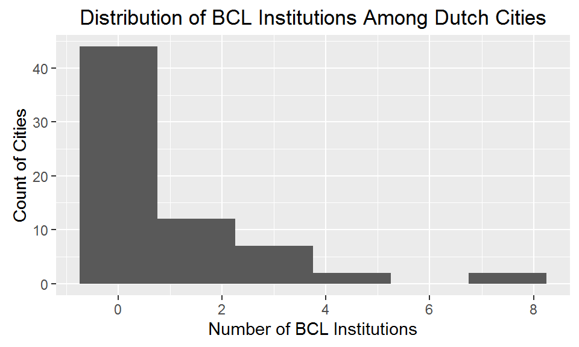

Regardless, analysis will be performed for both independent variables.

## 2.2 Dependent Variables

There are three dependent variables, attempting to show a mixture of human and economic capital. These might be be related or prerequisite to a common understanding of commercial development, as it occurred in the Low Countries during the 16th and 17th centuries.

*Book_share* is the percentage of total Low Country bookeditions (2,378 in the Netherlands and Belgium between 1470 and 1500) produced in a given city before 1500. The number of book editions is taken from [Incunabula Short Title Catalogue of British Library](http://www.bl.uk/catalogues/istc/index.html).

*Literacy* (male, 1600): percentage of bridegrooms from a given city (33 available) who signed name on marriage registration instead of stamping fingerprint; 12,152 total observations at the Amsterdam Archives. *Literacy* (male, 1860) is data collected from 19th-century birth registers in the Historical Sample of the Netherlands (HSN), aggregated by authors from provinces to municipalities.

*City growth* (1400-1560) for 67 cities with 1,000 or more residents in 1400. Most population estimates are the work of recent scholars, from whom the Authors took the most relevant and compelling figures. Given the disparities between municipalities and centuries–rapid growth overall and especially in urban areas following the agricultural and industrial revolutions–it makes sense to use the logarithm of population percentage change.

## 2.3 Exogenous Variables

There are a number of variables that, while (ideally) uncorrelated with the independent variable, may have influence over the dependent variable. It is necessary to include these in the more-robust regression procedures in order to control for their confounding impact, thereby isolating the partial effect of BCL affiliation.

*Schools_before_1400*: Proxy for a city’s educational infrastructure prior to and independent of BCL affiliation

*Population_1300; _1400; growth_1300_1400*: Control for the impact of city size and prior urbanization trends upon the growth 1400-1560

The presence of other major religous orders. The five largest Dutch monastic movements were Modern Devotion (which included BCL), Tertiarians, Franciscans, Beghards and Beguines, and Cistercians.

Other proxy variables for economic potential and wherewithal: location on a river or seaport; distance to a Roman colony or road (trade route); membership or affiliation with the Hanseatic League (international trade). Distances to various cities also factor in as needed; for instance, any regression attempting to explain literacy should include *Distance_to_Amsterdam*, since all literacy records before the 19th century are from the Amsterdam Archives and might be biased toward those cities closer to Amsterdam.

## 2.4 Summary Statistics

The following table includes means, standard deviations, and two-sample t-test P-values for the dependent, instrumental, and exogenous variables in each of the two crucial samples: those Dutch cities unaffiliated with the Brethren of the Common Life (**BCL=0**), and those affiliated (**BCL=1**). [Cf. Authors’ Table 4, p. 841] The t-tests are two-tailed; that is, the null hypothesis for each variable is the difference between BCL and non-BCL cities should be trivial in either direction.

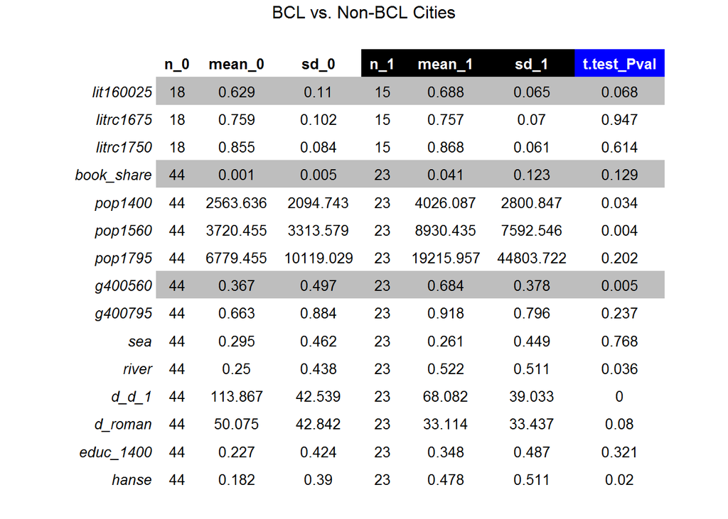

## 2.5 Discussion: Book Share

Book production is a good national metric for cultural capital and economic development. Estimates of per capita gross-domestic product in Western European nation-regions, reflecting scholars’ direct claims about economic wellbeing, are plotted against per capita book edition printing in the same nation-regions. Here for 1500:

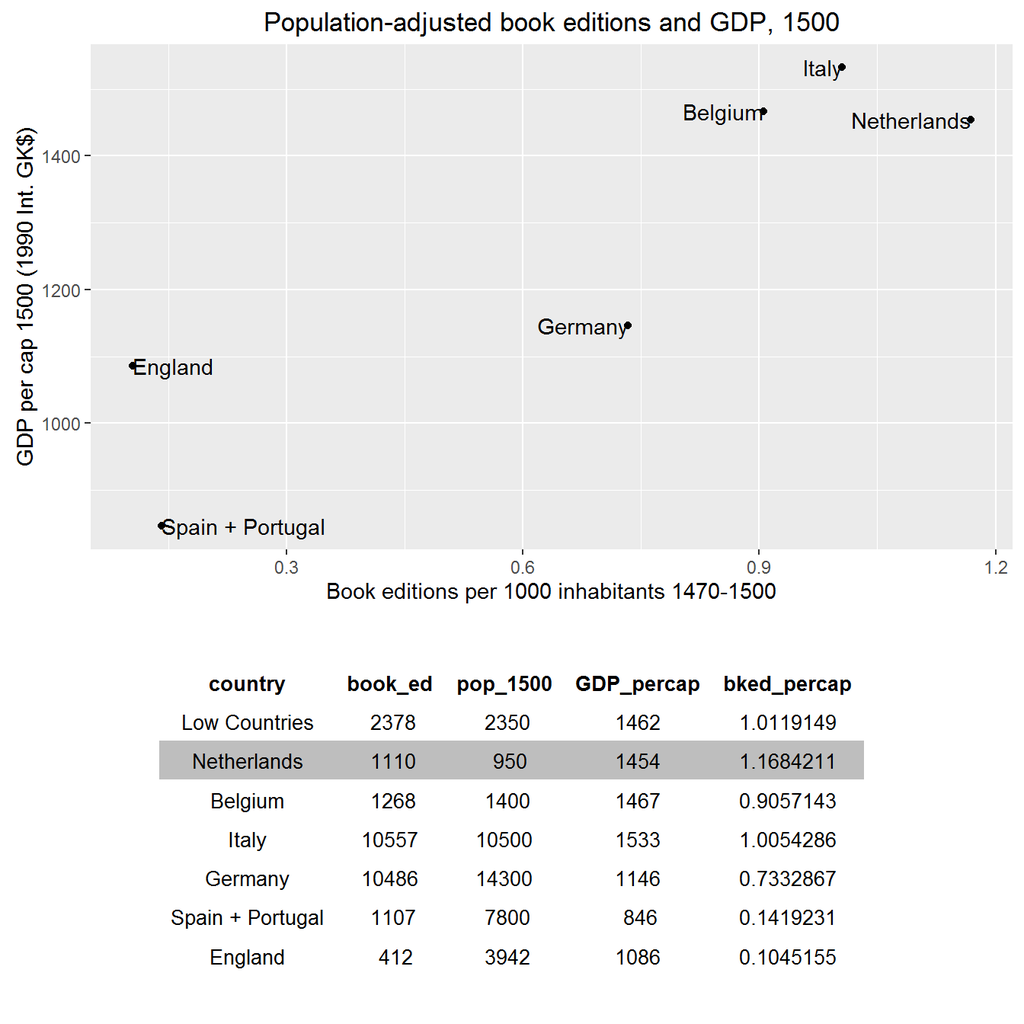

The two per capita variables, representing human and economic capital, have a correlation of 0.901.

*Notes:* Per the authors [p. 834], population and per-capita GDP numbers are taken from [Maddison Project](http://www.ggdc.net/maddison/maddison-project/home.htm). Unfortunately, no GDP estimates are available for France before 1820 (at which point they are rather detailed), even though France and French-speaking Switzerland contain 5,437 book editions and 15.3 million people (over a quarter of Western Europe) by 1500. The book publication figures group together Germany with German-speaking Austria and Switzerland, although GDP figures are only available for the first. The same is true of Spain and Portugal, although only the former has a GDP estimate for 1500; Portugal’s tends to be higher than Spain’s (from 1550 on, and probably earlier due to its earlier Reconquista), but the Spanish estimate (probably too low) was used for both.

Of course, only a handful of municipalities are responsible for most of the printing in a given nation. This unfortunately means that *book_share* is not a particularly useful metric for representing human-capital differences *inter urbis*.

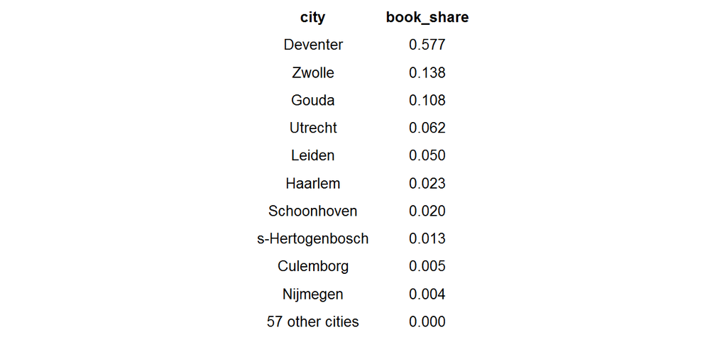

Only five of those cities with nonzero book production also appear in the Amsterdam Archives data offering literacy in 1600. Comparing *book_share* and *literacy* among those five:

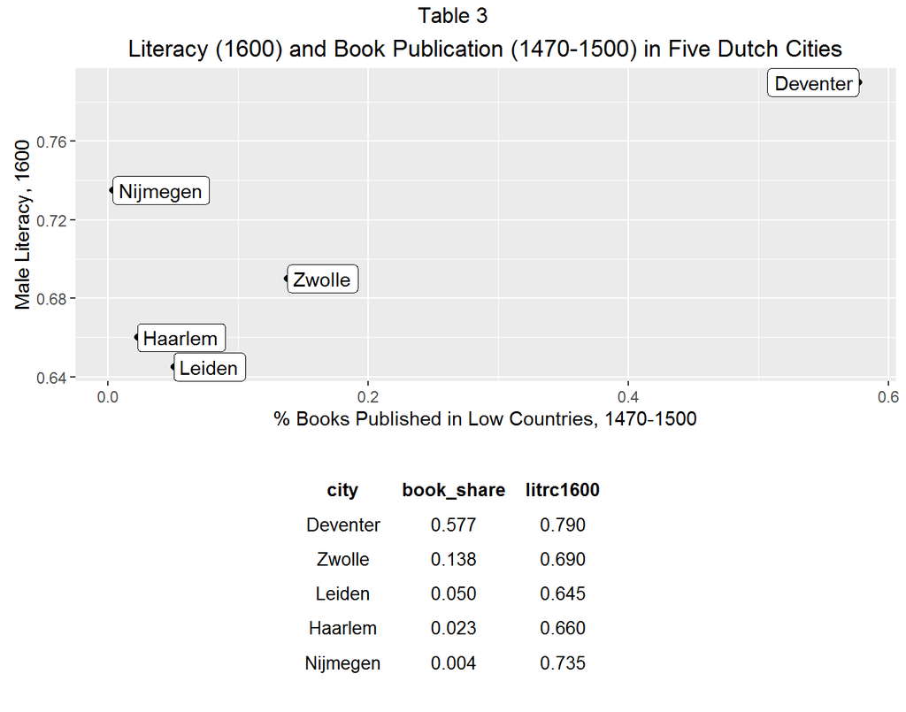

These cities are nontrivial, having significant populations and the oldest university in the Netherlands (Leiden, 1575). The correlation between book publication (1470-1500) and literacy (1600) in the five cities is 0.774, which is rather strong. The sample is simply too small to achieve a statistically significant OLS estimator, working with only 3 degrees of freedom.

While I am hesitant to give book production the same weight as the authors did, it is satisfying to know that there are strong correlations between this variable, national per capita GDP, and city-by-city literacy rates. Going forward, I will retain the dependent variables population growth and literacy rates as the two twin markers of economic growth and human capital development, respectively.

# 3 The Models (OLS + 2SLS)

While the problem seems simple on its face – comparing proxy variables between two samples to draw conclusions about economic development – the ‘treatment’ of BCL presence was not, in a sense, randomly assigned. The Modern Devotion movement did not conduct double-blind trials in a random sample of Dutch cities. BCL affiliation needs to be independent of ‘error’ in the analysis due to measurement, treatment, or historical fluctuations.

Following this rationale, the Authors opt for a Two-Stage Least Squares approach using an Instrumental Variable, in line with scholarship attempting historical causality. In this case, since Geert Groote founded the BCL movement in Deventer, the scholars use “distance from Deventer” as the instrument. BCL affiliation insofar as new houses would be formed, most likely, in cities with geographical proximity; priests and brothers would train or visit Deventer, as it became a site of the broader Modern Devotion movement. That said, there is nothing in the Groote’s biography to suggest that he founded BCL in Deventer for any particular, local reason. It was a reasonably populous city with an intellectual climate, but among all options (e.g. Utrecht, Nigmegen, Haarlem, Leiden) its initial BCL ‘treatment’ was effectively random. In both senses, then, *Distance_from_Deventer* should be both relevant and exogenous – that is, correlated with BCL affiliation and uncorrelated with any exogenous variables controlled for the 2SLS procedure.

One criticism is the Authors’ use of ‘as-the-crow-flies’ geometric distances. While this is understandable and perhaps unavoidable, land travel in the medieval world was highly difficult, and it is highly unlikely that a journey’s distance and time were linearly related.

## 3.1 Instrument Relevance

For OLS estimators, the number listed is the partial slope, with its associated P-value in parantheses.

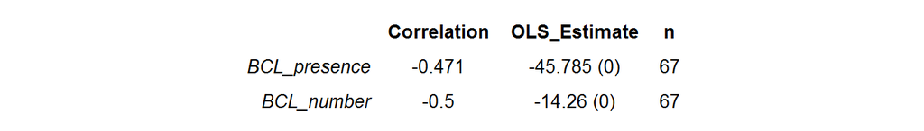

The likelihood of BCL presence and the number of BCL institutions decrease with greater distance from Deventer, so it passes the test of relevance.

## 3.2 Instrument Exogeneity

It is only useful to test exogeneity against variable phenomena which predate BCL’s founding in Deventer. While distance from Deventer is certainly correlated with 16th-century urbanization and literacy rates in 1600, we use earlier population figures and the school presence proxy to test Deventer’s historical independence. While it is useful to include population figures in the robust regressions, only 15 of 67 cities have population estimates in 1300. The 1300-1400 trendline is still important for controlling population growth 1400-1560, so the numbers are included also in testing the exogeneity of the instrument.

[figure not shown]

Unsurprisingly, the Modern Devotion affiliation is correlated with BCL affiliation, as are the Beghards and Beguines. Since the interest overall is in the influence of contemporary religious movements, and since they shared some institutional frameworks, this is expected.

Otherwise, only the Hanseatic League is significant in regression with *Distance_to_Deventer*. The Authors spend a section of their paper repeating all 2SLS procedures with control for the *Hanse* dummy variable – essentially, one more variable in the regression, or splitting the sample and performing the same procedure on Hanseatic and non-Hanseatic cities – but I am unconcerned for a few reasons:

- The correlation between *Distance_to_Deventer* and *Hanse* is only -0.254, which is not particularly high.
- The Hanseatic League had unclear membership criteria (full member, trading partner, non-aggression signatory, etc.), so the Authors had to make some educated guesses.
- In its early form, the League essentially mapped a geographic region: some northeastern Dutch, northwest German, and southern Scandinavian cities. Since Deventer is in the northeastern quadrant of the Netherlands, it makes sense that two geographic variables are correlated.
- Membership in the Hanseatic League, while important for import-export figures, probably did not have any (potentially confounding) impact upon literacy rates or even urbanization, which are the proxies for human-capital development in this study. (Indeed the Authors went on to prove that *Hanse* did not have a significant partial slope in OLS for any dependent variable.)

Given the results of the two tests, *Distance_to_Deventer* is both relevant and exogenous for instrumental use. The Authors go further, devoting a section to placebo testing – i.e. testing distances to other Dutch cities, with insignificant results – to prove the singular benefit of the instrument.

# 4 Results + Interpretation

Four OLS + 2SLS series are performed: literacy in 1600; population growth in the Netherlands, 1400-1560; population growth expanded to Belgian and German cities; and literacy in 1860, by which point the effects of BCL affiliation were long over.

## 4.1 Literacy in 1600

The depedent variable is male literacy in 1600. For the sake of comparison, regressions are shown both with and without instrumentation. Exogenous variables are *Log_Population_1400* (under presumption that a city’s prior size might affect its prior literacy rate) and *Distance_to_Amsterdam* (as mentioned above, literacy data collection may skew toward Greater Amsterdam).

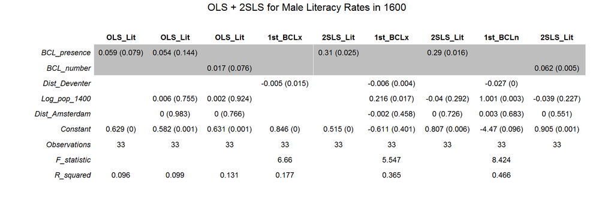

The BCL variable estimates increase sharply, with significantly lower P-values, in the two-stage procedure. Identifying the geographic instrument separated out some model error and presents a clearer, more compelling picture.

Overall, a city’s BCL affiliation was associated with a 30-point increase in literacy rates (out of 100%) over its peer cities, controlled for size. When counting building by building, each BCL facility was associated with a 6-point increase.

## 4.2 Population Growth, 1400-1560

The depedent variable is population growth, 1400-1560. For the sake of comparison, regressions are shown both with and without instrumentation. Exogenous variables are *Log_Population_1400* (under presumption that a city’s prior size might affect its potential growth), *Sea* and *River* (as the 15th-16th century marked the beginning of seafaring mercantile prosperity), and *Roman* (since Roman settlement status denotes an older, more-established municipality).

The Authors note that population growth was, at that time, related closely to economic potential – “a post-Malthusian regiume in which human capital translates into population growth.” [p. 848] They also reestimated the full OLS model, excluding cities that grew or shrank more than 100% in the 160-year period. [Note: Since a city that loses 100% of its population would have stopped existing, the Authors just excluded those cities that grew rapidly.]

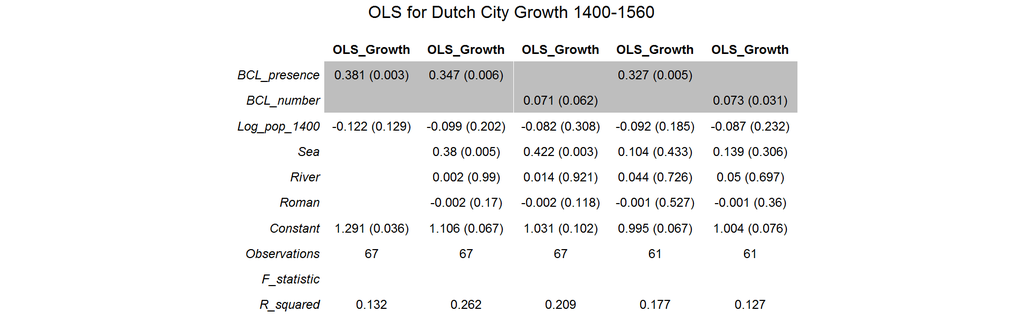

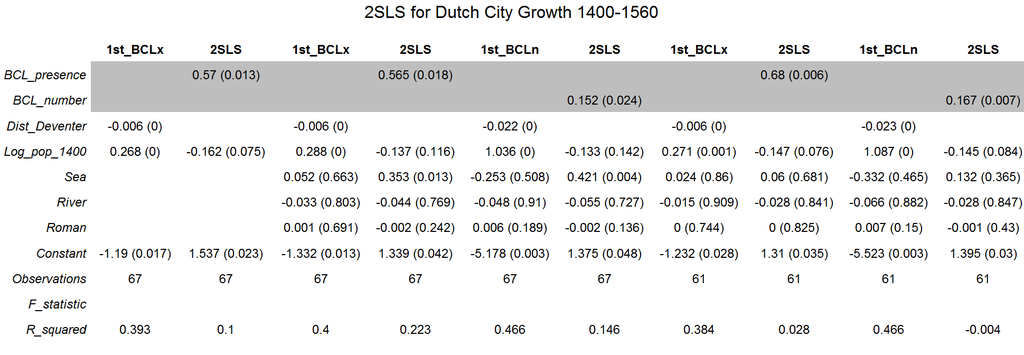

Again, the partial slopes for BCL variables are much higher in the 2SLS procedure. They are about the same whether or not other exogenous variables (mostly insignificant) are present in the regression. In general, BCL presence was associated with a 57-point growth rate increase (out of 100%) compared to peer cities, controlled for size and geographic location; individual BCL facilities could expect to contribute 15 points each. One intriguing feature: having a seaport was also linked to an increase between 35 and 42 points, until the 6 fastest-growing cities – those that had doubled in size or more by 1560 – were removed from the sample. *Sea* has a much lower coefficient and an insignificant P-value in the last four regressions. The cities removed: Amsterdam, Enkhuizen, Rotterdam, Schiedam, Sneek, s-Gravenhage, all of which are located on the sea. If we control for the rise of mercantile seafaring in the 16th century, then, BCL has an even higher partial effect on population growth: 68 points overall, 17 points per institution.

## 4.3 Growth in Greater Netherlands

Using data from correspondence and monastic records, we can also include 12 Belgian and 12 German cities alongside the 67 Dutch ones. The only indepedent variable for these is BCL affiliation, since there is no reliable metric for measuring the number of instutions in the additional cities. (The Authors note that there is only information available for larger cities, especially in Germany, even though BCL set up institutions in several smaller ones.) This is the same analysis as before. All 91 cities are in the first six regressions; the last three are with the 83 cities which experienced less-than-100% population increase between 1400-1560.

[figure not shown]

The same trends persist when Belgian and German cities are included. The 2SLS procedure is both more precise and more compelling. Seaport possession is nearly tied with BCL for greatest positive impact upon urban population growth, until the 8 fastest-growing cities are removed: Amsterdam, Antwerpen, Brugge, Enkhuizen, Rotterdam, Schiedam, Sneek, s-Gravenhage. Seven of those eight have seaports. All told, BCL affiliation is associated with 42-46 more points than peer cities, and 49-50 among moderately-growing and landed cities.

## 4.4 Effect Diminishment

Literacy rates in 1860 are more reliable, available for all cities, and in all likelihood unaffected by BCL instutions present centuries earlier. What we will test for instead, out of academic curiosity, is the percentage of Protestants in a city. After the Reformation, the Netherlands became a haven for Calvinists, Reformed, and some Anabaptists, all of whom put significant emphasis on literacy.

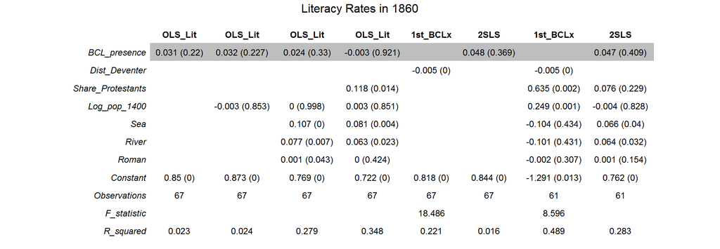

As expected, the partial effect of BCL affiliation has ‘worn away’ by the 19th century, while share of Protestants is both significant and nontrivial.

# 5 Conclusions + Criticisms

It is worth restating that the Authors’ paper is both highly informative and eminently enjoyable. Geert Groote does not receive much mention outside of comprehensive exams in European History, and too often the 14th century is regarded as a backward Dark Age, lying in wait of Renaissance and Reformation. That he founded an order which had remarkable impact in later centuries should not come as a surprise; that its effects can be quantified so clearly is rather remarkable. Expanding the study to Belgium and West Germany confirmed that it was not a political or geographic fluke; extending to the 19th century provided a useful sanity check. Of course, we should be careful about applying standards of ‘human capital’ or ‘economic development’ that may be anachronistic – there have been many cultures of notable genius whose great accomplishments were not within a written tradition or urban setting – but, after the invention of the printing press and expansion of mercantile middle and working classes, it is safe to say that widespread literacy and dense urbanization really can speak for the technical and thought industries of the early modern and modern eras.

Of course, the focus of this study has been to reexamine the quantitative approaches and rationale, taking the historical study more or less at face value. In my opinion, the Authors placed too much weight in the discussion of *book_share* as an indicator of intellectual capital, when there were so few observations from which to work. On top of this, book plates were in a sense self-reported, such that a publisher could (and not infrequently did) lie about the location of a given book’s publication – some cities having greater repute than others, and later with Protestants not always keen on buying books from Catholic city presses (and vice versa). The literacy and city-growth variables do enough as proxies for human-capital development, urbanization, and economic potential. There is also the fact that, where *book_share* and *literacy_1600* data are both available, they are highly and positively correlated (0.774); by contrast high literacy in 1600 and city population growth 1400-1560 are *negatively* correlated (-0.409). BCL affiliation may have been one of few factors with positive influence upon both literacy and urban population.

# 6 Appendix

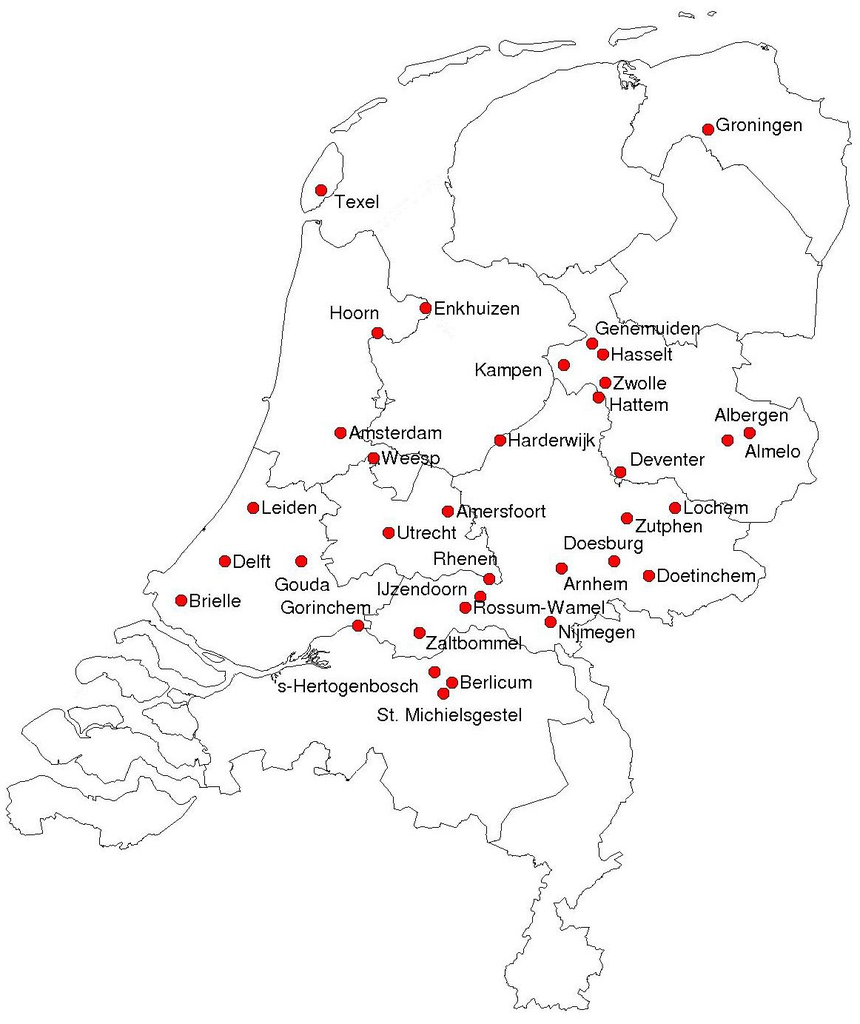

Authors’ image, showing the location of Dutch cities important in the 14th-17th centuries.

```r
# 2.4 Summary Statistics

g_bcl0 <- data.frame(growth[growth$bcl_x==0,])
g_bcl1 <- data.frame(growth[growth$bcl_x==1,])
l_bcl0 <- data.frame(literacy[literacy$bcl_x==0,])
l_bcl1 <- data.frame(literacy[literacy$bcl_x==1,])

frame <- data.frame(n_0=0,mean_0=0,sd_0=0,n_1=0,mean_1=0,sd_1=0,t.test_Pval=0)

for (i in 1:3) {
  j <- c(5,3,4)[i]
  frame[i,] <-
    round(c(length(l_bcl0[,j]),mean(l_bcl0[,j]),sd(l_bcl0[,j]),
            length(l_bcl1[,j]),mean(l_bcl1[,j]),sd(l_bcl1[,j]),
            t.test(l_bcl0[,j],l_bcl1[,j],mu=0)$p.value),3)
  rownames(frame)[i] <- names(literacy)[j]
}

for (i in 4:15) {
  j <- c(13,2,3,4,6,7,9,10,17,8,15,32)[i-3]
  frame[i,] <-
    round(c(length(g_bcl0[,j]),mean(g_bcl0[,j]),sd(g_bcl0[,j]),
            length(g_bcl1[,j]),mean(g_bcl1[,j]),sd(g_bcl1[,j]),
            t.test(g_bcl0[,j],g_bcl1[,j],mu=0)$p.value),3)
  rownames(frame)[i] <- names(growth)[j]
}

tt1 <- ttheme_minimal(
  base_size = 10,
  core = list(bg_params=list(fill=c("white","grey")[c(2,1,1,2,1,1,1,2,1,1,1,1,1,1,1)])),
  colhead = list(fg_params=list(col=c(rep(c("black","white"),each=3),"white")),
                 bg_params=list(fill=c(rep(c("white","black"),each=3),"blue")))
)

tbl <- tableGrob(frame,theme=tt1)
grid.arrange(tbl,top="BCL vs. Non-BCL Cities")

# 2.5 Discussion: Book Share

df <- data.frame(
  country = c("Low Countries","Netherlands","Belgium","Italy","Germany","Spain + Portugal","England"),
  book_ed = c(2378,1110,1268,10557,10486,1107,412),
  pop_1500 = c(2350,950,1400,10500,14300,7800,3942),
  GDP_percap = c(1462,1454,1467,1533,1146,846,1086)
)
df$bked_percap <- df$book_ed/df$pop_1500

# make pretty charts
tt2 <- ttheme_minimal(
  base_size = 10,
  core = list(bg_params=list(fill=c("white","grey")[c(1,2,1,1,1,1,1)]))
)

tbl <- tableGrob(df,theme=tt2,rows=NULL)
plt <- ggplot(df[-1,],aes(x=bked_percap,y=GDP_percap,label=country)) + geom_point() + geom_text(hjust="inward") + labs(title="Population-adjusted book editions and GDP, 1500",x="Book editions per 1000 inhabitants 1470-1500",y="GDP per cap 1500 (1990 Int. GK$)")
grid.arrange(plt,tbl,nrow=2,heights=c(3,2))

df <- data.frame(rbind(growth[growth$book_share!=0,c("city","book_share")],c(paste(sum(growth$book_share==0),"other cities"),0))); df$book_share <- round(as.numeric(df[,2]),3); df <- arrange(df,desc(book_share))

grid.arrange(tableGrob(df,theme=tt,rows=NULL))

# compare literacy (1600) and book production (1470-1500) figures
book_litrc <- merge(literacy,growth[growth$book_share!=0,],by="city")
df <- book_litrc[,c("city","book_share","lit160025")]; df[,2] <- round(as.numeric(df[,2]),3); df <- arrange(df,desc(book_share)); names(df)[3] <- "litrc1600"

# make pretty charts
tbl <- tableGrob(df,theme=tt,rows=NULL)
plt <- ggplot(book_litrc,aes(x=book_share,y=lit160025,label=city)) + geom_point() + geom_label(hjust="inward") + labs(title="Literacy (1600) and Book Publication (1470-1500) in Five Dutch Cities",x="% Books Published in Low Countries, 1470-1500",y="Male Literacy, 1600")
grid.arrange(plt,tbl,nrow=2,heights=c(3,2),top="Table 3")

# 3.1 Instrument Relevance

ivtest <- function(var,iv="d_d_1",data=growth) {
  c(
    "Correlation" = round(cor(data[,var],data[,iv]),3),
    "OLS_Estimate" = paste(paste(round(summary(
      lm(data[,iv]~data[,var])
    )$coefficients[2,c(1,4)],3),collapse=" ("),")",sep=""),
    "n" = length(growth$bcl_x)
  )
}

df <- rbind(
  "BCL_presence"=ivtest("bcl_x"),
  "BCL_number"=ivtest("bcl_n")
)

grid.arrange(tableGrob(df,theme=tt))

# Instrument Exogeneity

df <- rbind(
  "Schools_before_1400"=ivtest("educ_1400"),
  "Log_population_1300"=ivtest("lpop1300",data=growth1300),
  "Log_population_1400"=ivtest("lpop1400"),
  "Pop_growth_1300_1400"=ivtest("g300400",data=growth1300),
  "All_monasteries"=ivtest("dum_monast_all5"),
  "Modern_Devotion"=ivtest("dum_md5"),
  "Tertiarians"=ivtest("dum_tertiar5"),
  "Franciscans"=ivtest("dum_franciscan5"),
  "Beghards_and_Beguines"=ivtest("dum_beghard5"),
  "Cistercians"=ivtest("dum_cistercien5"),
  "Hanseatic_League"=ivtest("hanse")
)
grid.arrange(tableGrob(df,theme=tt))

# 4.1 Literacy in 1600

model1 <- lm(lit160025~bcl_x,data=literacy)
model2 <- lm(lit160025~bcl_x+lxpop1400+xd_ams_1,data=literacy)
model3 <- lm(lit160025~bcl_n+lxpop1400+xd_ams_1,data=literacy)
model4 <- lm(bcl_x~d_d_1,data=literacy)
model5 <- ivreg(lit160025~bcl_x|d_d_1,data=literacy)
model6 <- lm(bcl_x~d_d_1+lxpop1400+xd_ams_1,data=literacy)
model7 <- ivreg(lit160025~bcl_x+lxpop1400+xd_ams_1|d_d_1+lxpop1400+xd_ams_1,data=literacy)
model8 <- lm(bcl_n~d_d_1+lxpop1400+xd_ams_1,data=literacy)
model9 <- ivreg(lit160025~bcl_n+lxpop1400+xd_ams_1|d_d_1+lxpop1400+xd_ams_1,data=literacy)

coefs <- function(model) {
  df <- summary(model)$coefficients
  paste(round(df[,1],3)," (",round(df[,4],3),")",sep="")
}

vec <- c(rep("",9))

vectorize <- function(model,cfs,F_st=FALSE,R_sq=TRUE) {
  vec[cfs] <- coefs(model) # where the variable partial slopes should go in table
  vec[length(vec)-2] <- sum(summary(model)$df[c(1:2)]) # number of observations, vars + df
  vec[length(vec)-1] <- if(F_st==TRUE) { round(summary(model)$fstatistic[1],3) } else { "" }
  vec[length(vec)] <- if(R_sq==TRUE) { round(summary(model)$r.squared,3) } else { "" }
  vec
}

df <- data.frame(cbind(
  vectorize(model1,c(6,1)),
  vectorize(model2,c(6,1,4,5)),
  vectorize(model3,c(6,2,4,5)),
  vectorize(model4,c(6,3),F_st=T),
  vectorize(model5,c(6,1),R_sq=F),
  vectorize(model6,c(6,3,4,5),F_st=T),
  vectorize(model7,c(6,1,4,5),R_sq=F),
  vectorize(model8,c(6,3,4,5),F_st=T),
  vectorize(model9,c(6,2,4,5),R_sq=F)),
  row.names=c("BCL_presence","BCL_number","Dist_Deventer","Log_pop_1400","Dist_Amsterdam","Constant","Observations","F_statistic","R_squared")
); names(df) <- c(rep("OLS_Lit",3),rep(c("1st_BCLx","2SLS_Lit"),2),c("1st_BCLn","2SLS_Lit"))

tt3 <- ttheme_minimal(
  base_size = 9,
  core = list(bg_params=list(fill=c("white","grey")[c(2,2,rep(1,7))]))
)

grid.arrange(tableGrob(df,theme=tt3),top="OLS + 2SLS for Male Literacy Rates in 1600")

# 4.2 Population Growth, 1400-1560
# OLS
growth100 <- growth[abs(growth$g400560)<1,]

model1 <- lm(g400560~bcl_x+lpop1400,data=growth)
model2 <- lm(g400560~bcl_x+lpop1400+sea+river+d_roman,data=growth)
model3 <- lm(g400560~bcl_n+lpop1400+sea+river+d_roman,data=growth)
model4 <- lm(g400560~bcl_x+lpop1400+sea+river+d_roman,data=growth100)
model5 <- lm(g400560~bcl_n+lpop1400+sea+river+d_roman,data=growth100)

vec <- c(rep("",10))

df <- data.frame(cbind(
  vectorize(model1,c(7,1,3)),
  vectorize(model2,c(7,1,3,4,5,6)),
  vectorize(model3,c(7,2,3,4,5,6)),
  vectorize(model4,c(7,1,3,4,5,6)),
  vectorize(model5,c(7,2,3,4,5,6))),
  row.names=c("BCL_presence","BCL_number","Log_pop_1400","Sea","River","Roman","Constant","Observations","F_statistic","R_squared")
); names(df) <- rep("OLS_Growth",5)

tt4 <- ttheme_minimal(
  base_size = 9,
  core = list(bg_params=list(fill=c("white","grey")[c(2,2,rep(1,8))]))
)

grid.arrange(tableGrob(df,theme=tt4),top="OLS for Dutch City Growth 1400-1560")

# 2SLS
model1 <- lm(bcl_x~d_d_1+lpop1400,data=growth)
model2 <- ivreg(g400560~bcl_x+lpop1400|d_d_1+lpop1400,data=growth)
model3 <- lm(bcl_x~d_d_1+lpop1400+sea+river+d_roman,data=growth)
model4 <- ivreg(g400560~bcl_x+lpop1400+sea+river+d_roman|d_d_1+lpop1400+sea+river+d_roman,data=growth)
model5 <- lm(bcl_n~d_d_1+lpop1400+sea+river+d_roman,data=growth)
model6 <- ivreg(g400560~bcl_n+lpop1400+sea+river+d_roman|d_d_1+lpop1400+sea+river+d_roman,data=growth)
model7 <- lm(bcl_x~d_d_1+lpop1400+sea+river+d_roman,data=growth100)
model8 <- ivreg(g400560~bcl_x+lpop1400+sea+river+d_roman|d_d_1+lpop1400+sea+river+d_roman,data=growth100)
model9 <- lm(bcl_n~d_d_1+lpop1400+sea+river+d_roman,data=growth100)
model10 <- ivreg(g400560~bcl_n+lpop1400+sea+river+d_roman|d_d_1+lpop1400+sea+river+d_roman,data=growth100)

vec <- rep("",11)

df <- data.frame(cbind(
  vectorize(model1,c(8,3,4)),
  vectorize(model2,c(8,1,4)),
  vectorize(model3,c(8,3,4,5,6,7)),
  vectorize(model4,c(8,1,4,5,6,7)),
  vectorize(model5,c(8,3,4,5,6,7)),
  vectorize(model6,c(8,2,4,5,6,7)),
  vectorize(model7,c(8,3,4,5,6,7)),
  vectorize(model8,c(8,1,4,5,6,7)),
  vectorize(model9,c(8,3,4,5,6,7)),
  vectorize(model10,c(8,2,4,5,6,7))),
  row.names=c("BCL_presence","BCL_number","Dist_Deventer","Log_pop_1400","Sea","River","Roman","Constant","Observations","F_statistic","R_squared")
); names(df) <- c(rep(c("1st_BCLx","2SLS"),2),c("1st_BCLn","2SLS"),c("1st_BCLx","2SLS"),c("1st_BCLn","2SLS"))

tt5 <- ttheme_minimal(
  base_size = 9,
  core = list(bg_params=list(fill=c("white","grey")[c(2,2,rep(1,9))]))
)

grid.arrange(tableGrob(df,theme=tt5),top="2SLS for Dutch City Growth 1400-1560")

# 4.3 Growth in Greater Netherlands

hinterland100 <- hinterland[abs(hinterland$g400560)<1,]

model1 <- lm(g400560~bcl_x+lpop1400,data=growth)
model2 <- lm(g400560~bcl_x+lpop1400+sea+river+d_roman,data=hinterland)
model3 <- lm(bcl_x~d_d_1+lpop1400,data=hinterland)
model4 <- ivreg(g400560~bcl_x+lpop1400|d_d_1+lpop1400,data=hinterland)
model5 <- lm(bcl_x~d_d_1+lpop1400+sea+river+d_roman,data=hinterland)
model6 <- ivreg(g400560~bcl_x+lpop1400+sea+river+d_roman|d_d_1+lpop1400+sea+river+d_roman,data=hinterland)
model7 <- lm(g400560~bcl_x+lpop1400+sea+river+d_roman,data=hinterland100)
model8 <- lm(bcl_x~d_d_1+lpop1400+sea+river+d_roman,data=hinterland100)
model9 <- ivreg(g400560~bcl_x+lpop1400+sea+river+d_roman|d_d_1+lpop1400+sea+river+d_roman,data=hinterland100)

vec <- c(rep("",10))

df <- data.frame(cbind(
  vectorize(model1,c(7,1,3)),
  vectorize(model2,c(7,1,3,4,5,6)),
  vectorize(model3,c(7,2,3)),
  vectorize(model4,c(7,1,3)),
  vectorize(model5,c(7,2,3,4,5,6)),
  vectorize(model6,c(7,1,3,4,5,6)),
  vectorize(model7,c(7,1,3,4,5,6)),
  vectorize(model8,c(7,2,3,4,5,6)),
  vectorize(model9,c(7,1,3,4,5,6))),
  row.names=c("BCL_presence","Dist_Deventer","Log_pop_1400","Sea","River","Roman","Constant","Observations","F_statistic","R_squared")
); names(df) <- c(rep("OLS_Growth",3),rep(c("1st_BCLx","2SLS"),3))

tt6 <- ttheme_minimal(
  base_size = 9,
  core = list(bg_params=list(fill=c("white","grey")[c(2,rep(1,9))]))
)

grid.arrange(tableGrob(df,theme=tt6),top="OLS + 2SLS for Regional City Growth 1400-1560")

# 4.4 Effect Diminishment

model1 <- lm(xlit4080~bcl_x,data=growth)
model2 <- lm(xlit4080~bcl_x+lpop1400,data=growth)
model3 <- lm(xlit4080~bcl_x+lpop1400+sea+river+d_roman,data=growth)
model4 <- lm(xlit4080~bcl_x+mprotw+lpop1400+sea+river+d_roman,data=growth)
model5 <- lm(bcl_x~d_d_1,data=growth)
model6 <- ivreg(xlit4080~bcl_x|d_d_1,data=growth)
model7 <- lm(bcl_x~d_d_1+mprotw+lpop1400+sea+river+d_roman,data=growth100)
model8 <- ivreg(xlit4080~bcl_x+mprotw+lpop1400+sea+river+d_roman|d_d_1+mprotw+lpop1400+sea+river+d_roman,data=growth100)

vec <- rep("",11)

df <- data.frame(cbind(
  vectorize(model1,c(8,1)),
  vectorize(model2,c(8,1,4)),
  vectorize(model3,c(8,1,4,5,6,7)),
  vectorize(model4,c(8,1,3,4,5,6,7)),
  vectorize(model5,c(8,2),F_st=T),
  vectorize(model6,c(8,1)),
  vectorize(model7,c(8,2,3,4,5,6,7),F_st=T),
  vectorize(model8,c(8,1,3,4,5,6,7))),
  row.names=c("BCL_presence","Dist_Deventer","Share_Protestants","Log_pop_1400","Sea","River","Roman","Constant","Observations","F_statistic","R_squared")
); names(df) <- c(rep("OLS_Lit",4),rep(c("1st_BCLx","2SLS"),2))

tt7 <- ttheme_minimal(
  base_size = 9,
  core = list(bg_params=list(fill=c("white","grey")[c(2,rep(1,10))]))
)

grid.arrange(tableGrob(df,theme=tt7),top="Literacy Rates in 1860")
```